# Dimension Reduction Analysis - Website Satisfaction Survey

PSI CA Part Three - Dimension Reduction

Andrea Gherpelli

# Introduction

This analysis documents a dimension reduction using a dataset derived from a Website Satisfaction Survey that assesses various aspects of user experience with an e-commerce website. The dataset, available from Kaggle, was created by Faisal, C. M. N., Gonzalez-Rodriguez, M., FernandezLanvin, D., and Andres-Suarez, J. De (2017) and investigates how web design attributes (such as typography, color, interactivity, and navigation) contribute to user trust, satisfaction, and loyalty.

The hypothesis tested in this analysis is whether the survey responses can be reduced to a smaller set of latent variables (dimensions) that represent specific aspects of user satisfaction. In particular, we aim to explore if interactivity, navigation, typography, and color can be grouped into meaningful factors that help explain the overall user experience on the website.

To explore this question, Principal Component Analysis (PCA) is used. PCA will help to reduce the dimensions of the data and identify the underlying latent variables contributing to user satisfaction.

# 2. Data Description

**Typography** (q1 - q3)

1. It is easy to read the text on this website with the used font type and size.
2. The font color is appealing on this website.
3. The text alignment and spacing on this website make the text easy to read.

   **Color** (q4 - q5)
4. The color scheme of this website is appealing.
5. The use of color or graphics enhances navigation.

   **Interactivity** (q9 - q13)
6. This website provides adequate feedback to assess my progression when I perform a task.
7. This website offers customization.
8. This website offers versatility of ordering process.
9. This website provides content tailored to the individual.
10. In this website everything is consistent.

    **Navigation** (q14 - q18)
11. Navigation aids serve as a logical road map for buying.
12. Obviousness of buying button and links in this website.
13. It is easy to personalize or narrow buying process.
14. It is easy to learn to use the website.
15. This website supports reversibility of action.

```r
# Create a data frame to store the results
# Define the set of questions to process
question_vars <- c("q1", "q2", "q3", "q4", "q5", "q9", "q10",
                   "q11", "q12", "q13", "q14", "q15", "q16", "q17")

# Initialize the results dataframe
results <- data.frame(
  "Question" = question_vars,
  "Frequency" = rep("", length(question_vars)),
  "Median" = numeric(length(question_vars)),
  "IQR" = numeric(length(question_vars))
)

# Loop through the defined questions
for (i in seq_along(question_vars)) {
  v_name <- question_vars[i]

  # Check if the column exists and has data
  if (v_name %in% colnames(satData) && length(satData[[v_name]]) > 0) {

    # Frequency count (table of responses)
    freq_count <- table(factor(satData[[v_name]], levels = 1:5))
    results$Frequency[i] <- paste(paste(names(freq_count), freq_count, sep = ": "), collapse = ", ")

    # Median
    results$Median[i] <- median(satData[[v_name]], na.rm = TRUE)

    # IQR
    results$IQR[i] <- IQR(satData[[v_name]], na.rm = TRUE)
  }
}

# Print the results
results %>%
  kable(
    col.names = c("Question", "Frequency Counts", "Median", "IQR")
  ) %>%
  kable_styling(full_width = FALSE, position = "center")
```

| Question | Frequency Counts | Median | IQR |
| --- | --- | --- | --- |
| q1 | 1: 3, 2: 0, 3: 1, 4: 2, 5: 2 | 9 | 3 |
| q2 | 1: 1, 2: 1, 3: 1, 4: 2, 5: 3 | 8 | 2 |
| q3 | 1: 1, 2: 2, 3: 1, 4: 3, 5: 5 | 9 | 2 |
| q4 | 1: 0, 2: 1, 3: 3, 4: 4, 5: 3 | 8 | 3 |
| q5 | 1: 0, 2: 2, 3: 0, 4: 1, 5: 6 | 8 | 2 |
| q9 | 1: 1, 2: 2, 3: 5, 4: 2, 5: 7 | 7 | 3 |
| q10 | 1: 1, 2: 2, 3: 7, 4: 4, 5: 12 | 6 | 3 |
| q11 | 1: 2, 2: 0, 3: 1, 4: 5, 5: 8 | 7 | 2 |
| q12 | 1: 3, 2: 0, 3: 5, 4: 3, 5: 10 | 7 | 4 |
| q13 | 1: 2, 2: 0, 3: 0, 4: 1, 5: 5 | 8 | 3 |
| q14 | 1: 1, 2: 0, 3: 0, 4: 3, 5: 6 | 8 | 2 |
| q15 | 1: 2, 2: 2, 3: 0, 4: 1, 5: 7 | 8 | 2 |
| q16 | 1: 2, 2: 1, 3: 1, 4: 3, 5: 9 | 7 | 3 |
| q17 | 1: 2, 2: 1, 3: 1, 4: 0, 5: 3 | 8 | 3 |

**Table 1: Descriptive Statistics for Questions used in Dimension Reduction**

## 2.1 Screen the correlation matrix

```r
#create a correlation matrix (these are just some methods)
satMatrix<-cor(satData)
round(satMatrix, 2)
```

```
##       q1   q2   q3   q4   q5   q9  q10  q11  q12  q13  q14  q15  q16  q17
## q1  1.00 0.73 0.60 0.57 0.61 0.03 0.07 0.33 0.10 0.23 0.31 0.41 0.10 0.32
## q2  0.73 1.00 0.59 0.74 0.63 0.19 0.26 0.44 0.24 0.29 0.38 0.39 0.22 0.38
## q3  0.60 0.59 1.00 0.65 0.55 0.19 0.16 0.25 0.15 0.25 0.39 0.31 0.19 0.39
## q4  0.57 0.74 0.65 1.00 0.59 0.07 0.15 0.35 0.15 0.20 0.36 0.30 0.23 0.30
## q5  0.61 0.63 0.55 0.59 1.00 0.33 0.27 0.45 0.42 0.39 0.47 0.56 0.31 0.51
## q9  0.03 0.19 0.19 0.07 0.33 1.00 0.57 0.50 0.59 0.30 0.37 0.50 0.58 0.41
## q10 0.07 0.26 0.16 0.15 0.27 0.57 1.00 0.57 0.69 0.55 0.53 0.45 0.58 0.44
## q11 0.33 0.44 0.25 0.35 0.45 0.50 0.57 1.00 0.64 0.57 0.59 0.53 0.72 0.61
## q12 0.10 0.24 0.15 0.15 0.42 0.59 0.69 0.64 1.00 0.49 0.46 0.54 0.68 0.38
## q13 0.23 0.29 0.25 0.20 0.39 0.30 0.55 0.57 0.49 1.00 0.69 0.48 0.53 0.68
## q14 0.31 0.38 0.39 0.36 0.47 0.37 0.53 0.59 0.46 0.69 1.00 0.49 0.54 0.53
## q15 0.41 0.39 0.31 0.30 0.56 0.50 0.45 0.53 0.54 0.48 0.49 1.00 0.45 0.66
## q16 0.10 0.22 0.19 0.23 0.31 0.58 0.58 0.72 0.68 0.53 0.54 0.45 1.00 0.54
## q17 0.32 0.38 0.39 0.30 0.51 0.41 0.44 0.61 0.38 0.68 0.53 0.66 0.54 1.00
```

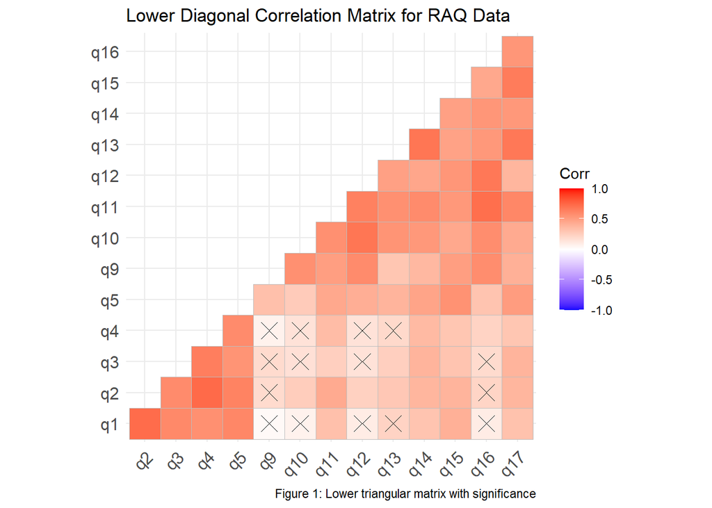

```r
# Generate the p-value matrix for significance testing
p.mat <- ggcorrplot::cor_pmat(satData)

# . Display only the lower diagonal of the correlation matrix
ggcorrplot::ggcorrplot(satMatrix,
                       title = "Lower Diagonal Correlation Matrix for RAQ Data",
                       p.mat = p.mat,
                       sig.level = 0.05,
                       type = "lower") +
  labs(caption = "Figure 1: Lower triangular matrix with significance")
```

# 3. Generate Statistics to Check if Data is Suitable for Dimension Reduction

## 3.1 Check that our variables are sufficiently correlated for dimension reduction (Bartlett’s Test)

If Bartlett’s test is statistically significant it suggests that the variables are correlated and a PCA/FA would be useful.  
Bartlett, Maurice S. “Tests of significance in factor analysis.” British journal of psychology (1950).

```r
psych::cortest.bartlett(satData)
```

```
## R was not square, finding R from data
```

```
## $chisq
## [1] 667.4326
##
## $p.value
## [1] 1.482751e-88
##
## $df
## [1] 91
```

## 3.2 Check that there is enough variance in your variables that could be caused by an underlying factor/dimension (KMO)

High values close to 1 suggest that PCA/FA might be useful. Values over 0.8 or over are considered strong. Anything less than 0.5 suggests that PCA/FA won’t be useful.  
Kaiser, H. F., & Rice, J. (1974). Little jiffy, mark IV. Educational and psychological measurement, 34(1), 111-117.

```r
#KMO:
psych::KMO(satData)
```

```
## Kaiser-Meyer-Olkin factor adequacy
## Call: psych::KMO(r = satData)
## Overall MSA =  0.81
## MSA for each item =
##   q1   q2   q3   q4   q5   q9  q10  q11  q12  q13  q14  q15  q16  q17
## 0.72 0.81 0.78 0.74 0.86 0.81 0.89 0.89 0.75 0.82 0.86 0.81 0.84 0.74
```

## 3.3 Check for collinearity and redundancy (Determinant)

Check if it will be difficult to extract factors as they will not be distinct enough. Inspect determinant and check to see if it is greater than 0.00001. Field, A. P., Miles, J., & Field, Z. (2012). Discovering statistics using R, Andy Field, Jeremy Miles, Zoë Field.

```r
#Determinant (As this is PCA do not worry if this is not > 0.00001 - you don't need to report it)
det(cor(satData))
```

```
## [1] 4.376917e-05
```

## Report

Taken together, these results demonstrate that the data is highly suitable for principal component analysis and that dimension reduction is warranted.

# 4. Dimension Reduction Using PCA (without rotation)

Form: pcModel<-principal(dataframe/R-matrix, nfactors = number of factors, rotate = “method of rotation”, scores = TRUE)  
For PCA we know how many components it is possible to find  
The principal function will work out the loadings of each variable onto each component, i.e. the proportion each component explained and the cumulative proportion of variance explained.

```r
pc1 <-  principal(satData, nfactors = length(satData), rotate = "none")#Conduct the PCA extracting the same number of components as there are variables
pc1#output all details of the PCA
```

```
## Principal Components Analysis
## Call: principal(r = satData, nfactors = length(satData), rotate = "none")
## Standardized loadings (pattern matrix) based upon correlation matrix
##      PC1   PC2   PC3   PC4   PC5   PC6   PC7   PC8   PC9  PC10  PC11  PC12
## q1  0.54  0.67  0.00 -0.12 -0.23  0.10  0.16  0.30  0.16  0.00  0.04  0.14
## q2  0.66  0.58  0.15  0.12 -0.17  0.05  0.23 -0.05 -0.14 -0.10  0.14 -0.11
## q3  0.57  0.57  0.05  0.08  0.48 -0.07  0.03  0.04  0.29  0.07 -0.09 -0.10
## q4  0.57  0.62  0.13  0.29  0.02 -0.13 -0.11 -0.27 -0.17  0.15  0.06  0.02
## q5  0.73  0.37  0.10 -0.21 -0.02  0.14 -0.35 -0.08 -0.04 -0.29 -0.12  0.12
## q9  0.59 -0.42  0.45 -0.22  0.30 -0.09  0.12  0.15 -0.20 -0.16  0.10 -0.04
## q10 0.67 -0.45  0.13  0.20  0.06  0.32  0.30 -0.18  0.00  0.05 -0.15  0.18
## q11 0.81 -0.21  0.02  0.14 -0.32 -0.25  0.04  0.12 -0.03 -0.02 -0.25 -0.17
## q12 0.70 -0.44  0.31  0.06 -0.14  0.21 -0.20 -0.07  0.25  0.02  0.06 -0.16
## q13 0.71 -0.24 -0.54  0.10  0.02  0.14  0.03 -0.07  0.08 -0.17  0.21 -0.08
## q14 0.75 -0.09 -0.32  0.23  0.18  0.17 -0.17  0.28 -0.25  0.12 -0.05  0.00
## q15 0.75 -0.06 -0.01 -0.52 -0.08  0.08 -0.04 -0.05 -0.06  0.36  0.06 -0.03
## q16 0.72 -0.43  0.09  0.21 -0.05 -0.36 -0.11  0.07  0.13  0.05  0.15  0.22
## q17 0.76 -0.08 -0.37 -0.30  0.07 -0.28  0.14 -0.19  0.01 -0.08 -0.08  0.02
##      PC13  PC14 h2       u2 com
## q1   0.09  0.10  1  2.2e-16 3.3
## q2  -0.21 -0.08  1  1.1e-16 3.3
## q3  -0.01 -0.07  1  0.0e+00 3.8
## q4   0.16  0.09  1 -1.1e-15 3.8
## q5   0.00 -0.07  1 -6.7e-16 3.0
## q9   0.10  0.04  1  1.7e-15 4.8
## q10  0.02 -0.03  1  2.0e-15 3.7
## q11  0.10 -0.06  1  1.1e-15 2.3
## q12 -0.07  0.13  1  1.7e-15 3.4
## q13  0.16 -0.06  1  1.7e-15 2.9
## q14 -0.11  0.05  1  2.1e-15 2.8
## q15  0.02 -0.09  1  2.2e-16 2.5
## q16 -0.07 -0.07  1  2.0e-15 3.1
## q17 -0.12  0.14  1  1.0e-15 2.7
##
##                        PC1  PC2  PC3  PC4  PC5  PC6  PC7  PC8  PC9 PC10 PC11
## SS loadings           6.58 2.50 0.90 0.74 0.57 0.54 0.42 0.38 0.35 0.33 0.23
## Proportion Var        0.47 0.18 0.06 0.05 0.04 0.04 0.03 0.03 0.03 0.02 0.02
## Cumulative Var        0.47 0.65 0.71 0.77 0.81 0.85 0.88 0.90 0.93 0.95 0.97
## Proportion Explained  0.47 0.18 0.06 0.05 0.04 0.04 0.03 0.03 0.03 0.02 0.02
## Cumulative Proportion 0.47 0.65 0.71 0.77 0.81 0.85 0.88 0.90 0.93 0.95 0.97
##                       PC12 PC13 PC14
## SS loadings           0.20 0.16 0.10
## Proportion Var        0.01 0.01 0.01
## Cumulative Var        0.98 0.99 1.00
## Proportion Explained  0.01 0.01 0.01
## Cumulative Proportion 0.98 0.99 1.00
##
## Mean item complexity =  3.2
## Test of the hypothesis that 14 components are sufficient.
##
## The root mean square of the residuals (RMSR) is  0
##  with the empirical chi square  0  with prob <  NA
##
## Fit based upon off diagonal values = 1
```

# 5. Deciding which components to retain (PCA)

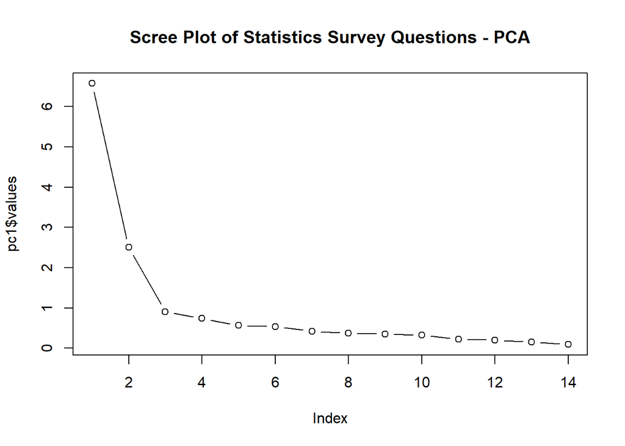

```r
#Create the scree plot
plot(pc1$values, type = "b", main="Scree Plot of Statistics Survey Questions - PCA")
```

Variance explanined by each component:

```r
#Print the variance explained by each component
pc1$Vaccounted
```

```
##                             PC1       PC2        PC3        PC4        PC5
## SS loadings           6.5760487 2.5045091 0.90332679 0.74448819 0.56732322
## Proportion Var        0.4697178 0.1788935 0.06452334 0.05317773 0.04052309
## Cumulative Var        0.4697178 0.6486113 0.71313461 0.76631234 0.80683543
## Proportion Explained  0.4697178 0.1788935 0.06452334 0.05317773 0.04052309
## Cumulative Proportion 0.4697178 0.6486113 0.71313461 0.76631234 0.80683543
##                             PC6        PC7        PC8        PC9       PC10
## SS loadings           0.5370596 0.42283585 0.37858880 0.35490328 0.32631996
## Proportion Var        0.0383614 0.03020256 0.02704206 0.02535023 0.02330857
## Cumulative Var        0.8451968 0.87539939 0.90244145 0.92779168 0.95110025
## Proportion Explained  0.0383614 0.03020256 0.02704206 0.02535023 0.02330857
## Cumulative Proportion 0.8451968 0.87539939 0.90244145 0.92779168 0.95110025
##                             PC11       PC12       PC13        PC14
## SS loadings           0.22821046 0.20168072 0.15927616 0.095429130
## Proportion Var        0.01630075 0.01440577 0.01137687 0.006816366
## Cumulative Var        0.96740100 0.98180677 0.99318363 1.000000000
## Proportion Explained  0.01630075 0.01440577 0.01137687 0.006816366
## Cumulative Proportion 0.96740100 0.98180677 0.99318363 1.000000000
```

Eigenvalues:

```r
#Print the Eigenvalues
pc1$values
```

```
##  [1] 6.57604869 2.50450910 0.90332679 0.74448819 0.56732322 0.53705964
##  [7] 0.42283585 0.37858880 0.35490328 0.32631996 0.22821046 0.20168072
## [13] 0.15927616 0.09542913
```

Loadings (sorted based on their contributions to the principal components):

```r
#Show the loadings of variables on to components
fa.sort(pc1$loading)
```

```
##
## Loadings:
##     PC1    PC2    PC3    PC4    PC5    PC6    PC7    PC8    PC9    PC10
## q11  0.806 -0.214         0.139 -0.316 -0.248         0.117
## q17  0.764        -0.371 -0.296        -0.278  0.135 -0.195
## q14  0.754        -0.323  0.234  0.177  0.173 -0.169  0.284 -0.249  0.119
## q15  0.749               -0.524                                     0.355
## q5   0.733  0.375        -0.214         0.137 -0.350               -0.286
## q16  0.715 -0.428         0.205        -0.365 -0.108         0.128
## q13  0.714 -0.237 -0.537                0.136                      -0.169
## q12  0.699 -0.442  0.305        -0.138  0.210 -0.198         0.252
## q10  0.671 -0.451  0.128  0.198         0.325  0.303 -0.177
## q2   0.656  0.577  0.152  0.125 -0.174         0.229        -0.138
## q9   0.594 -0.419  0.448 -0.216  0.299         0.119  0.153 -0.195 -0.163
## q1   0.539  0.669        -0.123 -0.226         0.165  0.302  0.161
## q4   0.567  0.619  0.135  0.290        -0.132 -0.113 -0.272 -0.172  0.149
## q3   0.565  0.567                0.478                       0.294
##     PC11   PC12   PC13   PC14
## q11 -0.253 -0.169  0.103
## q17               -0.120  0.138
## q14               -0.106
## q15
## q5  -0.125  0.122
## q16  0.148  0.224
## q13  0.208         0.159
## q12        -0.155         0.128
## q10 -0.154  0.178
## q2   0.143 -0.108 -0.210
## q9   0.103
## q1          0.144         0.102
## q4                 0.155
## q3
##
##                  PC1   PC2   PC3   PC4   PC5   PC6   PC7   PC8   PC9  PC10
## SS loadings    6.576 2.505 0.903 0.744 0.567 0.537 0.423 0.379 0.355 0.326
## Proportion Var 0.470 0.179 0.065 0.053 0.041 0.038 0.030 0.027 0.025 0.023
## Cumulative Var 0.470 0.649 0.713 0.766 0.807 0.845 0.875 0.902 0.928 0.951
##                 PC11  PC12  PC13  PC14
## SS loadings    0.228 0.202 0.159 0.095
## Proportion Var 0.016 0.014 0.011 0.007
## Cumulative Var 0.967 0.982 0.993 1.000
```

Communalities (assess the quality of representation of each variable in the analysis):

```r
#Output the communalities of variables across components (will be one for PCA since all the variance is used)
pc1$communality
```

```
##  q1  q2  q3  q4  q5  q9 q10 q11 q12 q13 q14 q15 q16 q17
##   1   1   1   1   1   1   1   1   1   1   1   1   1   1
```

Loadings above 0.3 (sorted):

```r
#Print the loadings above the level of 0.3
psych::print.psych(pc1, cut = 0.3, sort = TRUE)
```

```
## Principal Components Analysis
## Call: principal(r = satData, nfactors = length(satData), rotate = "none")
## Standardized loadings (pattern matrix) based upon correlation matrix
##     item  PC1   PC2   PC3   PC4   PC5   PC6   PC7   PC8  PC9  PC10 PC11 PC12
## q11    8 0.81                   -0.32
## q17   14 0.76       -0.37
## q14   11 0.75       -0.32
## q15   12 0.75             -0.52                               0.36
## q5     5 0.73  0.37                         -0.35
## q16   13 0.72 -0.43                   -0.36
## q13   10 0.71       -0.54
## q12    9 0.70 -0.44  0.31
## q10    7 0.67 -0.45                    0.32  0.30
## q2     2 0.66  0.58
## q9     6 0.59 -0.42  0.45
## q1     1 0.54  0.67                                0.30
## q4     4 0.57  0.62
## q3     3 0.57  0.57              0.48
##     PC13 PC14 h2       u2 com
## q11            1  1.1e-15 2.3
## q17            1  1.0e-15 2.7
## q14            1  2.1e-15 2.8
## q15            1  2.2e-16 2.5
## q5             1 -6.7e-16 3.0
## q16            1  2.0e-15 3.1
## q13            1  1.7e-15 2.9
## q12            1  1.7e-15 3.4
## q10            1  2.0e-15 3.7
## q2             1  1.1e-16 3.3
## q9             1  1.7e-15 4.8
## q1             1  2.2e-16 3.3
## q4             1 -1.1e-15 3.8
## q3             1  0.0e+00 3.8
##
##                        PC1  PC2  PC3  PC4  PC5  PC6  PC7  PC8  PC9 PC10 PC11
## SS loadings           6.58 2.50 0.90 0.74 0.57 0.54 0.42 0.38 0.35 0.33 0.23
## Proportion Var        0.47 0.18 0.06 0.05 0.04 0.04 0.03 0.03 0.03 0.02 0.02
## Cumulative Var        0.47 0.65 0.71 0.77 0.81 0.85 0.88 0.90 0.93 0.95 0.97
## Proportion Explained  0.47 0.18 0.06 0.05 0.04 0.04 0.03 0.03 0.03 0.02 0.02
## Cumulative Proportion 0.47 0.65 0.71 0.77 0.81 0.85 0.88 0.90 0.93 0.95 0.97
##                       PC12 PC13 PC14
## SS loadings           0.20 0.16 0.10
## Proportion Var        0.01 0.01 0.01
## Cumulative Var        0.98 0.99 1.00
## Proportion Explained  0.01 0.01 0.01
## Cumulative Proportion 0.98 0.99 1.00
##
## Mean item complexity =  3.2
## Test of the hypothesis that 14 components are sufficient.
##
## The root mean square of the residuals (RMSR) is  0
##  with the empirical chi square  0  with prob <  NA
##
## Fit based upon off diagonal values = 1
```

Visualize Contribution of variables to each component:

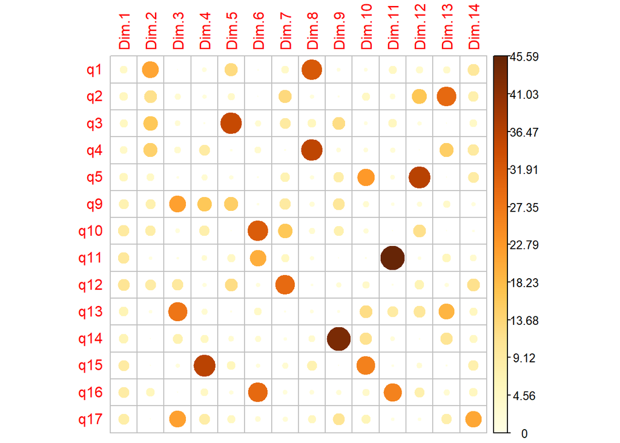

```r
#Visualize contribution of variables to each component
#Helps identify which variables are most influential in forming the principal components. May be useful for interpretation and feature selection.
#Use princomp function of PCA to get right class for use with factoextra functions
pcf=princomp(satData)
var <- factoextra::get_pca_var(pcf)
corrplot::corrplot(var$contrib, is.corr=FALSE)
```

Visualize Components and how manifest variables load:

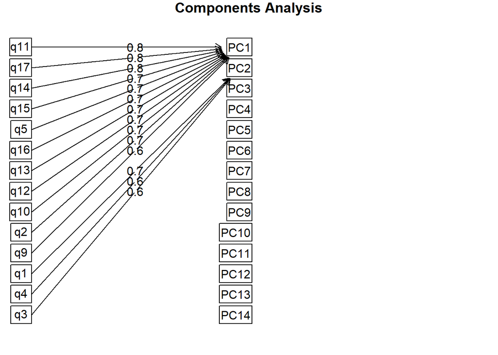

```r
#create a diagram showing the components and how the manifest variables load
fa.diagram(pc1)
```

Visualize Contributions of manifest to each component > 0.7:

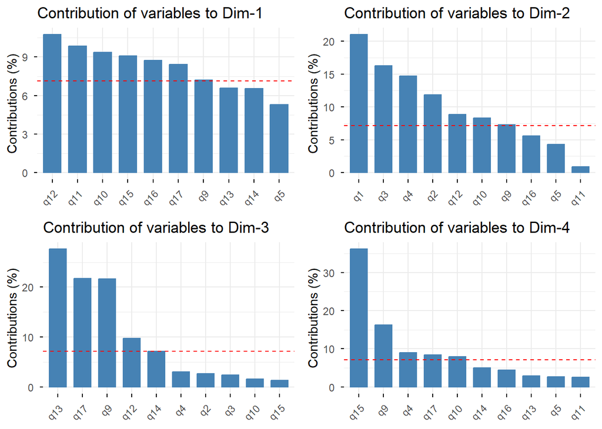

```r
# Generate the contribution plots for components 1, 2, 3 and 4
plot1 <- fviz_contrib(pcf, choice = "var", axes = 1, top = 10)
plot2 <- fviz_contrib(pcf, choice = "var", axes = 2, top = 10)
plot3 <- fviz_contrib(pcf, choice = "var", axes = 3, top = 10)
plot4 <- fviz_contrib(pcf, choice = "var", axes = 4, top = 10)
# Use grid.arrange() to place the plots in a grid
grid.arrange(plot1, plot2, plot3, plot4, ncol = 2)
```

# 6. Applying rotation (PCA)

Rotate options: varimax, quartimax, bentlerT, geominT, and bifactor do orthogonal rotations. oblimin, quartimin, simplimax, bentlerQ, geominQ and biquartimin are oblique transformations.

```r
#Apply rotation to try to refine the component structure
pc2 <-  principal(satData, nfactors = 4, rotate = "varimax")#Extracting 4 components with eigenvalues > 0.7 (Joliffe)
```

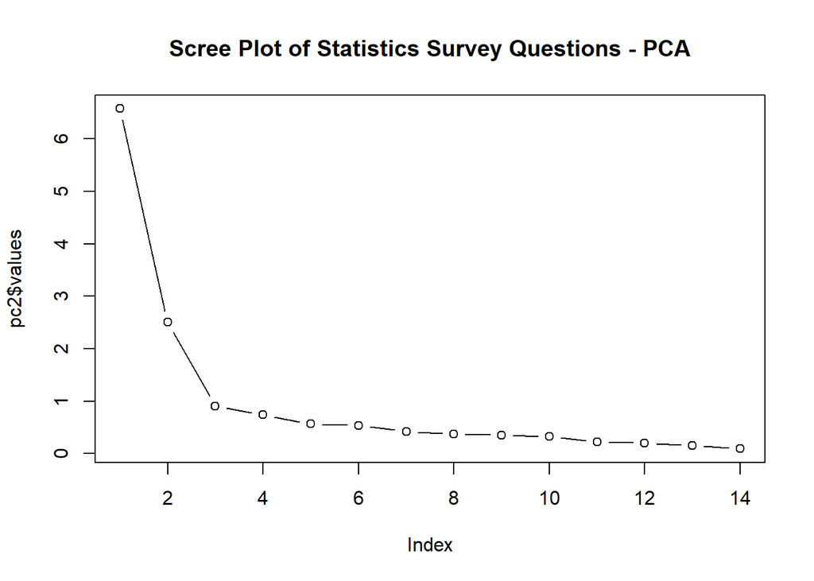

```r
#Create the scree plot
plot(pc2$values, type = "b", main="Scree Plot of Statistics Survey Questions - PCA")
```

Variance explanined by each component:

```r
#Print the variance explained by each component
pc2$Vaccounted
```

```
##                             RC2       RC1       RC3        RC4
## SS loadings           3.5945731 3.4073543 2.3319341 1.39451130
## Proportion Var        0.2567552 0.2433825 0.1665667 0.09960795
## Cumulative Var        0.2567552 0.5001377 0.6667044 0.76631234
## Proportion Explained  0.3350530 0.3176022 0.2173614 0.12998349
## Cumulative Proportion 0.3350530 0.6526551 0.8700165 1.00000000
```

Eigenvalues:

```r
#Print the Eigenvalues
pc2$values
```

```
##  [1] 6.57604869 2.50450910 0.90332679 0.74448819 0.56732322 0.53705964
##  [7] 0.42283585 0.37858880 0.35490328 0.32631996 0.22821046 0.20168072
## [13] 0.15927616 0.09542913
```

Loadings (sorted based on their contributions to the principal components):

```r
#Show the loadings of variables on to components
fa.sort(pc2$loading)
```

```
##
## Loadings:
##     RC2    RC1    RC3    RC4
## q4   0.877  0.112  0.123 -0.104
## q2   0.867  0.169  0.120
## q1   0.809         0.111  0.285
## q3   0.784         0.145  0.104
## q5   0.682  0.240  0.157  0.432
## q12         0.842  0.196  0.158
## q9          0.796         0.373
## q10         0.758  0.362
## q16         0.752  0.411
## q11  0.290  0.633  0.459  0.140
## q13  0.111  0.281  0.857  0.192
## q14  0.312  0.365  0.710
## q17  0.232  0.243  0.621  0.562
## q15  0.266  0.380  0.265  0.745
##
##                  RC2   RC1   RC3   RC4
## SS loadings    3.595 3.407 2.332 1.395
## Proportion Var 0.257 0.243 0.167 0.100
## Cumulative Var 0.257 0.500 0.667 0.766
```

Communalities (assess the quality of representation of each variable in the analysis):

```r
#Output the communalities of variables across components (will be one for PCA since all the variance is used)
pc2$communality
```

```
##        q1        q2        q3        q4        q5        q9       q10       q11
## 0.7540917 0.8021205 0.6499086 0.8070630 0.7334831 0.7763458 0.7092308 0.7153814
##       q12       q13       q14       q15       q16       q17
## 0.7804640 0.8628513 0.7369545 0.8402192 0.7457207 0.8145384
```

Loadings above 0.3 (sorted):

```r
#Print the loadings above the level of 0.3
psych::print.psych(pc2, cut = 0.3, sort = TRUE)
```

```
## Principal Components Analysis
## Call: principal(r = satData, nfactors = 4, rotate = "varimax")
## Standardized loadings (pattern matrix) based upon correlation matrix
##     item  RC2   RC1   RC3   RC4   h2   u2 com
## q4     4 0.88                   0.81 0.19 1.1
## q2     2 0.87                   0.80 0.20 1.1
## q1     1 0.81                   0.75 0.25 1.3
## q3     3 0.78                   0.65 0.35 1.1
## q5     5 0.68              0.43 0.73 0.27 2.1
## q12    9       0.84             0.78 0.22 1.2
## q9     6       0.80        0.37 0.78 0.22 1.4
## q10    7       0.76  0.36       0.71 0.29 1.5
## q16   13       0.75  0.41       0.75 0.25 1.6
## q11    8       0.63  0.46       0.72 0.28 2.4
## q13   10             0.86       0.86 0.14 1.4
## q14   11 0.31  0.36  0.71       0.74 0.26 1.9
## q17   14             0.62  0.56 0.81 0.19 2.6
## q15   12       0.38        0.74 0.84 0.16 2.1
##
##                        RC2  RC1  RC3  RC4
## SS loadings           3.59 3.41 2.33 1.39
## Proportion Var        0.26 0.24 0.17 0.10
## Cumulative Var        0.26 0.50 0.67 0.77
## Proportion Explained  0.34 0.32 0.22 0.13
## Cumulative Proportion 0.34 0.65 0.87 1.00
##
## Mean item complexity =  1.6
## Test of the hypothesis that 4 components are sufficient.
##
## The root mean square of the residuals (RMSR) is  0.05
##  with the empirical chi square  35.43  with prob <  0.72
##
## Fit based upon off diagonal values = 0.99
```

Visualize Components and how manifest variables load:

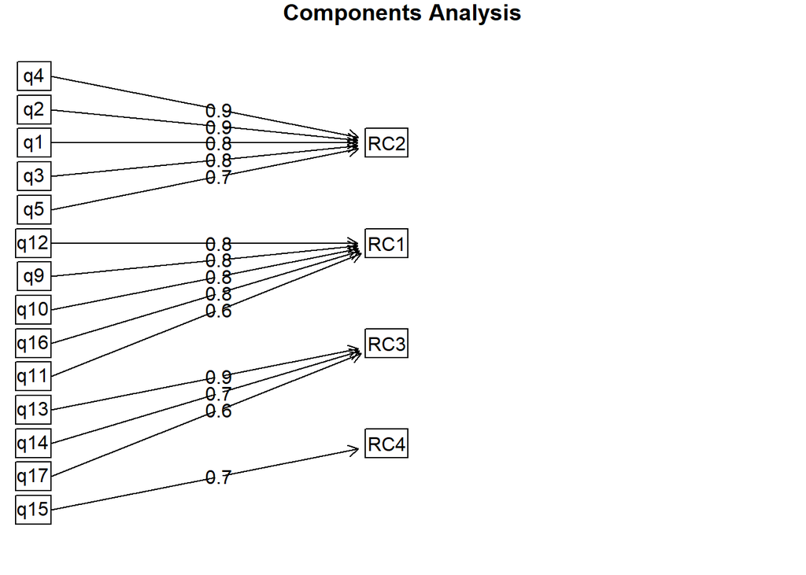

```r
#create a diagram showing the components and how the manifest variables load
fa.diagram(pc2)
```

Visualize Contributions of manifest to each component extracted:

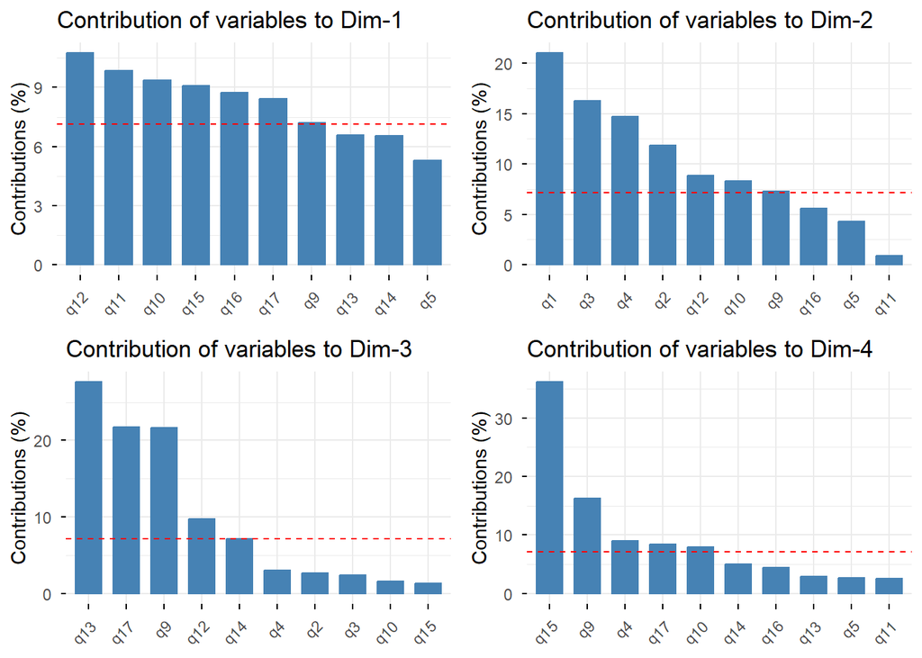

```r
# Generate the contribution plots for components 1, 2, 3 and 4
plot1 <- fviz_contrib(pcf, choice = "var", axes = 1, top = 10)
plot2 <- fviz_contrib(pcf, choice = "var", axes = 2, top = 10)
plot3 <- fviz_contrib(pcf, choice = "var", axes = 3, top = 10)
plot4 <- fviz_contrib(pcf, choice = "var", axes = 4, top = 10)
# Use grid.arrange() to place the plots in a grid
grid.arrange(plot1, plot2, plot3, plot4, ncol = 2)
```

## Report PCA

Loadings of the survey items onto these components were analyzed to identify their contribution. The sorted loadings and communalities indicated that all items loaded significantly onto at least one component, with communalities ranging between 0.65 and 0.86, confirming the quality of representation of the variables in the analysis. These loadings provide insights into the underlying structure of the survey responses.

These findings provide actionable insights for improving satisfaction survey dimensions, offering a nuanced understanding of how variables contribute to broader themes.

# 7. Reliability Analysis

If you know that variables are grouped, test each group as a separate scale. You are looking for Cronbach Alpha values e.g. psych::alpha(computerFear).

```r
# Group variables based on the identified categories
typographySatisfaction <- satData[, c("q1", "q2", "q3")]   # Typography-related satisfaction
colorSatisfaction <- satData[, c("q4", "q5")]              # Color-related satisfaction
interactivitySatisfaction <- satData[, c("q9", "q10", "q11", "q12", "q13")]  # Interactivity-related satisfaction
navigationSatisfaction <- satData[, c("q14", "q15", "q16", "q17")]    # Navigation-related satisfaction

# Output Cronbach's Alpha values
psych::alpha(typographySatisfaction, check.keys = TRUE) # Typography Satisfaction
```

```
##
## Reliability analysis
## Call: psych::alpha(x = typographySatisfaction, check.keys = TRUE)
##
##   raw_alpha std.alpha G6(smc) average_r S/N   ase mean  sd median_r
##       0.84      0.84    0.79      0.64 5.4 0.033  7.9 1.9      0.6
##
##     95% confidence boundaries
##          lower alpha upper
## Feldt     0.76  0.84  0.89
## Duhachek  0.78  0.84  0.90
##
##  Reliability if an item is dropped:
##    raw_alpha std.alpha G6(smc) average_r S/N alpha se var.r med.r
## q1      0.74      0.74    0.59      0.59 2.9    0.060    NA  0.59
## q2      0.75      0.75    0.60      0.60 3.0    0.058    NA  0.60
## q3      0.84      0.85    0.73      0.73 5.5    0.036    NA  0.73
##
##  Item statistics
##     n raw.r std.r r.cor r.drop mean  sd
## q1 73  0.89  0.89  0.82   0.74  8.0 2.2
## q2 73  0.88  0.89  0.82   0.74  7.9 2.0
## q3 73  0.85  0.84  0.69   0.64  7.8 2.2
##
## Non missing response frequency for each item
##       1    2    3    4    5    6    7    8    9   10 miss
## q1 0.04 0.00 0.01 0.03 0.03 0.07 0.10 0.21 0.25 0.27    0
## q2 0.01 0.01 0.01 0.03 0.04 0.08 0.12 0.25 0.25 0.19    0
## q3 0.01 0.03 0.01 0.04 0.07 0.08 0.08 0.15 0.27 0.25    0
```

```r
psych::alpha(colorSatisfaction, check.keys = TRUE) # Color Satisfaction
```

```
##
## Reliability analysis
## Call: psych::alpha(x = colorSatisfaction, check.keys = TRUE)
##
##   raw_alpha std.alpha G6(smc) average_r S/N  ase mean  sd median_r
##       0.74      0.74    0.59      0.59 2.9 0.06  7.5 1.7     0.59
##
##     95% confidence boundaries
##          lower alpha upper
## Feldt     0.59  0.74  0.84
## Duhachek  0.62  0.74  0.86
##
##  Reliability if an item is dropped:
##    raw_alpha std.alpha G6(smc) average_r S/N alpha se var.r med.r
## q4      0.69      0.59    0.35      0.59 1.5       NA     0  0.59
## q5      0.51      0.59    0.35      0.59 1.5       NA     0  0.59
##
##  Item statistics
##     n raw.r std.r r.cor r.drop mean  sd
## q4 73  0.91  0.89  0.69   0.59  7.4 2.0
## q5 73  0.88  0.89  0.69   0.59  7.5 1.8
##
## Non missing response frequency for each item
##       2    3    4    5    6    7    8    9   10 miss
## q4 0.01 0.04 0.05 0.04 0.18 0.14 0.15 0.23 0.15    0
## q5 0.03 0.00 0.01 0.08 0.12 0.19 0.29 0.14 0.14    0
```

```r
psych::alpha(interactivitySatisfaction, check.keys = TRUE) # Interactivity Satisfaction
```

```
##
## Reliability analysis
## Call: psych::alpha(x = interactivitySatisfaction, check.keys = TRUE)
##
##   raw_alpha std.alpha G6(smc) average_r S/N   ase mean  sd median_r
##       0.86      0.86    0.84      0.55   6 0.026    7 1.8     0.57
##
##     95% confidence boundaries
##          lower alpha upper
## Feldt     0.80  0.86  0.90
## Duhachek  0.81  0.86  0.91
##
##  Reliability if an item is dropped:
##     raw_alpha std.alpha G6(smc) average_r S/N alpha se  var.r med.r
## q9       0.85      0.85    0.82      0.58 5.6    0.028 0.0048  0.57
## q10      0.81      0.81    0.78      0.51 4.2    0.036 0.0141  0.53
## q11      0.82      0.82    0.79      0.53 4.5    0.033 0.0174  0.56
## q12      0.80      0.81    0.78      0.51 4.1    0.037 0.0115  0.56
## q13      0.85      0.85    0.82      0.59 5.8    0.028 0.0045  0.58
##
##  Item statistics
##      n raw.r std.r r.cor r.drop mean  sd
## q9  73  0.75  0.74  0.65   0.60  7.1 2.3
## q10 73  0.85  0.85  0.81   0.75  6.4 2.3
## q11 73  0.81  0.82  0.76   0.70  7.1 2.1
## q12 73  0.86  0.85  0.82   0.76  6.9 2.4
## q13 73  0.71  0.73  0.63   0.57  7.5 2.0
##
## Non missing response frequency for each item
##        1    2    3    4    5    6    7    8    9   10 miss
## q9  0.01 0.03 0.07 0.03 0.10 0.08 0.23 0.14 0.16 0.15    0
## q10 0.01 0.03 0.10 0.05 0.16 0.15 0.15 0.12 0.10 0.12    0
## q11 0.03 0.00 0.01 0.07 0.11 0.12 0.21 0.23 0.07 0.15    0
## q12 0.04 0.00 0.07 0.04 0.14 0.11 0.14 0.19 0.12 0.15    0
## q13 0.03 0.00 0.00 0.01 0.07 0.18 0.18 0.21 0.14 0.19    0
```

```r
psych::alpha(navigationSatisfaction, check.keys = TRUE)  # Navigation Satisfaction
```

```
##
## Reliability analysis
## Call: psych::alpha(x = navigationSatisfaction, check.keys = TRUE)
##
##   raw_alpha std.alpha G6(smc) average_r S/N   ase mean  sd median_r
##       0.82      0.82    0.79      0.54 4.6 0.034  7.6 1.7     0.53
##
##     95% confidence boundaries
##          lower alpha upper
## Feldt     0.74  0.82  0.88
## Duhachek  0.75  0.82  0.89
##
##  Reliability if an item is dropped:
##     raw_alpha std.alpha G6(smc) average_r S/N alpha se   var.r med.r
## q14      0.79      0.79    0.73      0.55 3.7    0.044 1.2e-02  0.54
## q15      0.78      0.78    0.70      0.54 3.5    0.045 3.9e-05  0.54
## q16      0.79      0.79    0.73      0.56 3.9    0.041 8.1e-03  0.53
## q17      0.74      0.74    0.66      0.49 2.9    0.053 2.0e-03  0.49
##
##  Item statistics
##      n raw.r std.r r.cor r.drop mean  sd
## q14 73  0.78  0.79  0.68   0.62  7.7 1.9
## q15 73  0.81  0.81  0.72   0.64  7.6 2.2
## q16 73  0.79  0.78  0.67   0.60  7.0 2.1
## q17 73  0.85  0.85  0.79   0.72  8.1 2.1
##
## Non missing response frequency for each item
##        1    2    3    4    5    6    7    8    9   10 miss
## q14 0.01 0.00 0.00 0.04 0.08 0.08 0.22 0.15 0.25 0.16    0
## q15 0.03 0.03 0.00 0.01 0.10 0.07 0.12 0.32 0.12 0.21    0
## q16 0.03 0.01 0.01 0.04 0.12 0.18 0.15 0.14 0.21 0.11    0
## q17 0.03 0.01 0.01 0.00 0.04 0.04 0.16 0.21 0.21 0.29    0
```

## Report Reliability Analysis

The **Typography Satisfaction** subscale demonstrated **high reliability**, with a Cronbach’s alpha of α = 0.84, indicating that the items measuring typography-related satisfaction are consistent.

The **Color Satisfaction** subscale showed a **moderate level of reliability**, with a Cronbach’s alpha of α = 0.74. While this is still considered acceptable, there is some room for improvement in the consistency of responses related to color satisfaction.

The **Interactivity Satisfaction** subscale exhibited **strong reliability**, with a Cronbach’s alpha of α = 0.86, indicating high consistency in responses regarding interactivity on the website.

The **Navigation Satisfaction** subscale also showed **high reliability**, with a Cronbach’s alpha of α = 0.82, suggesting that the items related to navigation are reliable and measure a coherent concept of navigation satisfaction.

All the subscales exhibit acceptable to strong reliability, with the Interactivity Satisfaction and Typography Satisfaction subscales being the most consistent. The Color Satisfaction subscale could benefit from further refinement, while the Navigation Satisfaction subscale shows strong internal consistency.

# Conclusion

The reliability analysis further supported the robustness of these dimensions, with most subscales demonstrating high internal consistency. Typography and interactivity satisfaction subscales were particularly reliable, reflecting their strong influence on user perceptions. While the color satisfaction subscale exhibited slightly lower reliability, its contribution remained statistically meaningful.

These findings underscore the nuanced interplay between different aspects of web design in shaping user satisfaction, as posited by Faisal et al. (2017). Interactivity and navigation, in particular, emerged as pivotal in supporting seamless and engaging user journeys. The results highlight opportunities to refine survey questions and enhance design practices to target areas such as color schemes, which may benefit from greater emphasis or differentiation.

Overall, this study provides actionable insights into how web design attributes converge to impact user trust, satisfaction, and loyalty. By focusing on the core dimensions identified, practitioners can prioritize design improvements that yield meaningful enhancements to the user experience.

# References

Cronbach, L. J. (1951). Coefficient alpha and the internal structure of tests. Psychometrika, 16, 297–334.

DeVellis, R. F. (2016). Scale development: Theory and applications (4th ed.). Sage Publications.

Hair, J. F., Black, W. C., Babin, B. J., & Anderson, R. E. (2010). Multivariate data analysis (7th ed.). Pearson Education.

Nunnally, J. C., & Bernstein, I. H. (1994). Psychometric theory (3rd ed.). McGraw-Hill.

Tavakol, M., & Dennick, R. (2011). Making sense of Cronbach’s alpha. International Journal of Medical Education, 2, 53–55.

Weiss, D. J., & Dawis, R. V. (2007). Assessing the reliability of scales in the Minnesota Satisfaction Questionnaire. Journal of Applied Psychology, 92, 111–122.

Bradburn, N. M., Sudman, S., & Wansink, B. (2004). Asking questions: The definitive guide to questionnaire design (2nd ed.). Jossey-Bass.